Theobio main page

# Ontario COVID-19 forecasts

[#MacTheobio COVID Modelling Group](https://mac-theobio.github.io/covid-19/)

Irena Papst* ([@irenapapst](https://twitter.com/irenapapst)), Michael Li* ([@MLiwz1](https://twitter.com/MLiwz1)), Ben Bolker ([@bolkerb](https://twitter.com/bolkerb)), Jonathan Dushoff ([@jd_mathbio](https://twitter.com/jd_mathbio)), David Earn ([@DavidJDEarn](https://twitter.com/davidjdearn))

McMaster University, Hamilton, Ontario, Canada, L8S 4K1

The first two authors contributed equally

Forecast date: 16 May 2021

*Post last updated: 20 Jun 2021*

# Context

Every two weeks, [our group](https://mac-theobio.github.io/covid-19/) provides COVID-19 infection report forecasts for the province of Ontario to the [Ontario Modelling Consensus Table](https://covid19-sciencetable.ca/our-partners/) (MCT), a partner of the [Ontario Science Advisory Table](https://covid19-sciencetable.ca) (SAT), which presents this information to the Health Coordination Table of the Ontario Ministry of Health.[^1] Other modelling groups also provide forecasts to the MCT. After reviewing all forecasts provided, the MCT provides consensus projections to the SAT.

Our forecasts are based on a [compartmental epidemic model](https://en.wikipedia.org/wiki/Compartmental_models_in_epidemiology) implemented in our publicly available [`McMasterPandemic`](https://github.com/bbolker/McMasterPandemic) R package, and involve statistical fits to [Ontario’s latest infection report data](https://covid-19.ontario.ca/data).

# Forecast overview

The forecast presented here was made on **16 May 2021** and submitted to the MCT for inclusion in the public briefing by the SAT on 20 May.

As in the 9 May forecast (presented [here](https://mac-theobio.github.io/forecasts/outputs/McMasterOntarioForecastsBlog2021-05-09)) we continue to estimate the effect of the 8 April stay-at-home order on transmission from the infection report data.

We have updated, and will continue to update, this post in order to show the [latest infection reports](https://covid-19.ontario.ca/data), but the forecasts themselves have not, and will not, be modified after the forecast date.

We are closely monitoring the situation with the new [B.1.617 variant of concern](https://www.who.int/publications/m/item/weekly-epidemiological-update-on-covid-19---11-may-2021) and will incorporate its effect into future forecasts if there is evidence that it is changing the epidemiology of SARS-CoV-2 in Ontario.

# Forecast results

The following figure gives the infection report forecasts (curves), with 95% confidence intervals as bands around each forecast curve. Observed infection reports to which the model was fit are plotted with **solid points**, while observations after the fact are included as **hollow points**.

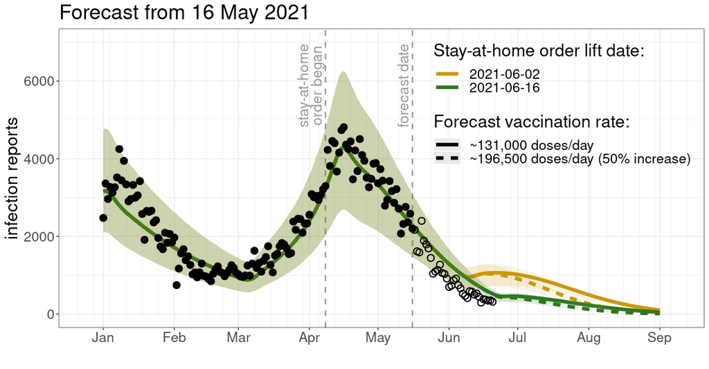

# Forecast details

## Vaccination assumptions

The baseline vaccination assumptions are that:

- doses are administered at the [reported dose administration rate](https://covid19tracker.ca/vaccinationtracker.html) up to the forecast date;
- all vaccines administered are 60% effective at preventing infection;
- if the vaccine confers immunity in an individual, immunity immediately takes effect 14 days after a first dose and does not wane;
- vaccines are administered at random in the population.

In the forecast period, the vaccination scenarios we explore are that:

1. vaccination continues at the seven-day average rate (from the week before the forecast date) of **~131,000 first doses/day** (*solid lines*);
2. the current average rate is increased by 50% to **~196,500 first doses/day** (*dashed lines*).

## Interventions

We estimate the reduction in transmission that has resulted from the 8 April stay-at-home order using infection report data up to the forecast date (16 May).

We explore two possible lift dates for the order:

1. 02 Jun 2021, as is currently planned;
2. 16 Jun 2021, extending the current stay-at-home order by an additional 14 days.

Once the stay-at-home order is lifted, we assume that the contact rate returns to its level just before the order came into effect. This change doesn’t become apparent in the forecasts for approximately two weeks, due to the delay between infections and infection reports. Of course, it is also possible that the degree of compliance with the stay-at-home order is changing over time, which adds additional uncertainty to our forecasts.

Related post: [Early prediction of Ontario’s third COVID-19 wave](https://mac-theobio.github.io/forecasts/outputs/ON_accuracy.html)

[Back to the MacTheobio COVID Modelling Group page](https://mac-theobio.github.io/covid-19/)

[^1]: This report has been written independently of the Ontario Modelling Consensus Table, the Ontario Science Advisory Table, and the Health Coordination Table. The views expressed in this report are solely the authors’.